# Guía de trabajo manipulación de base de datos

Diplomado en Análisis de datos con R para la acuicultura

Dr. José A. Gallardo y Dra. María Angélica Rueda.

Pontificia Universidad Católica de Valparaíso  
jose.gallardo@pucv.cl

06/05/2021

#### *Manipulación de bases de datos.*

La manipulación de datos es una de las actividades que más tiempo demanda ya que implica tanto dar el formato adecuado como aplicar transformaciones sobre las variables. Este proceso se lleva a cabo con el fin de generar un conjunto de datos acorde para su *posterior* análisis.

En síntesis la manipulación de datos se resume en cuatro operaciones:

**1.-** **Extraer subconjuntos de datos**

Ya sea por filas (por algún criterio) o por columnas (para realizar análisis especificos, donde no es necesario considerar todas las variables presentes en la base de datos original).

**2.-** **Transformarlos**

Realizar operaciones aritméticas o lógicas sobre los datos. En general cuando una **variable es continua** realizamos operaciones *aritméticas*, cuando es **categórica**, *lógicas*.

**3.-** **Obtener medidas resumen del conjunto de datos (ya sea por variable/s) o por grupos (criterio de agrupamiento por fila)**

Se puede resumir la información por variable calculando: valores promedio, desviaciones estándar, valores mínimos o máximos.

**4.-** **Compactar con otros conjuntos de datos**

Es posible que en tiempos posteriores surjan nuevas bases de datos que pueden enriquecer nuestros análisis, es muy útil combinar/compactar dicha información de forma homogénea en una sola base de datos.

#### *Visualización de datos.*

Es importante en la etapa de análisis exploratorio de datos, hacer representaciones gráficas porque permite:

- Detectar posibles valores atípicos “outliers”.
- Identificar la posible distribución subyacente de la variable respuesta **(Y)**.
- Analizar posibles relaciones/asociaciones entre la variable respuesta **(Y)** y la variable explicativa **(X)**.
- Sintetizar/mostrar la información proveniente de los datos, en forma amena y resumida.

*Nota*: La librería **ggplot2** contiene la función *ggplot()* con la que se generan gráficos tanto visualmente informativos como de agradable aspecto. Los objectos (dataframes) generados por *tidyverse* se pueden graficar con la función **ggplot()**.

#### **Objetivos de aprendizaje**

Los objetivos de aprendizaje de esta guía son:

**1**. Manipular y generar nuevas bases de datos y gráficos a partir de comandos de Tidyverse.

**2**. Elaborar un reporte dinámico en formato pdf.

#### **Comandos para manipular datos con Tidiverse**

[output not shown]

#### **Comandos para realizar gráficos con ggplot2 en Tidiverse**

| **Comandos** | **Función** |
| --- | --- |
| **ggplot():** | Permite hacer gráficos en el formato de ggplot2. |
| **geom_point():** | Argumento que se adiciona a la función ggplot() para generar diagramas de dispersión. |
| **geom_line():** | Argumento que se adiciona a la función ggplot() para generar diagramas de líneas. |
| **geom_col():** | Argumento que se adiciona a la función ggplot() para generar diagramas de barras. |
| **geom_histogram():** | Argumento que se adiciona a la función ggplot() para generar histogramas. |
| **geom_boxplot():** | Argumento que se adiciona a la función ggplot() para generar gráficos de cajas y bigotes. |
| **expand_limits(y=0):** | Argumento que se adiciona a la función ggplot() para que el eje de la **Y** empiece en cero. |
| **scale_x_log10():** | Argumento que se adiciona a la función ggplot() para que el eje de la **X** este en la escala de logaritmo en base 10. |
| **facet_wrap(~ variable):** | Argumento que se adiciona a la función ggplot() para que realice tantos gráficos según los niveles que tenga la variable. |

## **Ejercicios**

### **Ejercicio 1.** **Elaborar archivo Rmarkdown**

Elabore un archivo o file con extensión **.Rmd** y configurelo para exportar el resultado como un documento dinámico **pdf**. Utilice el siguiente ejemplo para completar la información de **metadatos**: Título: Reporte Manipulación de base de datos, nombre del autor: Su nombre.

Luego, guarde inmediatamente su script como **script_7_nombre_apellido.Rmd**. Al finalizar la actividad deberá exportar y almacenar este *script* en su carpeta drive de tareas.

### **Ejercicio 2.** **Configuración del reporte**

En el primer bloque de códigos o **chunk** configure los comandos de la siguiente manera *knitr::opts_chunk$set(echo = TRUE)* y cargue las librerías **readxl**, **stats**,**dplyr**, **tidyr** y **ggplot2** usando la función *library()*.

```r
knitr::opts_chunk$set(echo = TRUE)
library(readxl)
library(stats)
library(dplyr)
library(tidyr)
library(ggplot2)
```

### **Ejercicio 3.** **Importar la base de Datos1**

Cree un objeto llamado **datos1** e importe el set de datos **Datos1** usando la función *read_excel()* de la librería **readxl**. Explore el set de datos usando las funciones **head()** y **str()**.

```r
datos1 <- read_excel("Datos1.xlsx")
head(datos1)
```

```
## # A tibble: 6 x 5
##   Especies              Year ProdNac DispOvas Importacion
##   <chr>                <dbl>   <dbl>    <dbl>       <dbl>
## 1 Salmón del Atlántico  2016    361.     478.        3.32
## 2 Salmón Plateado       2016    125.     187.        0
## 3 Trucha Arcoiris       2016    101.     187.        0
## 4 Salmón del Atlántico  2017    427.     587.        7.54
## 5 Salmón Plateado       2017    109.     207.        0
## 6 Trucha Arcoiris       2017    106.     164.        0
```

```r
str(datos1)
```

```
## tibble[,5] [6 x 5] (S3: tbl_df/tbl/data.frame)
##  $ Especies   : chr [1:6] "Salmón del Atlántico" "Salmón Plateado" "Trucha Arcoiris" "Salmón del Atlántico" ...
##  $ Year       : num [1:6] 2016 2016 2016 2017 2017 ...
##  $ ProdNac    : num [1:6] 361 125 101 427 109 ...
##  $ DispOvas   : num [1:6] 478 187 187 587 207 ...
##  $ Importacion: num [1:6] 3.32 0 0 7.54 0 ...
```

### **Ejercicio 4.** **Filtrar información de la base de datos por algún criterio**

Del conjunto de datos **datos1** seleccione solo la información del **Year 2017** usando la función *filter()*, recuerde usar el simbolo **%>%** para que pueda realizar el filtrado.

```r
datos1 %>%
  filter(Year == 2017)
```

```
## # A tibble: 3 x 5
##   Especies              Year ProdNac DispOvas Importacion
##   <chr>                <dbl>   <dbl>    <dbl>       <dbl>
## 1 Salmón del Atlántico  2017    427.     587.        7.54
## 2 Salmón Plateado       2017    109.     207.        0
## 3 Trucha Arcoiris       2017    106.     164.        0
```

### **Ejercicio 5.** **Filtrar información de la base de datos por año y especie**

Del set de datos **datos1** seleccione solo la información del **Year 2016** y **Especie Salmón del Atlántico** usando la función *filter()*.

```r
datos1 %>%
  filter(Year == 2016, Especies == "Salmón del Atlántico")
```

```
## # A tibble: 1 x 5
##   Especies              Year ProdNac DispOvas Importacion
##   <chr>                <dbl>   <dbl>    <dbl>       <dbl>
## 1 Salmón del Atlántico  2016    361.     478.        3.32
```

### **Ejercicio 6.** **Calcular medidas resumen**

Del conjunto de datos **datos1** seleccione solo la información de la **Trucha Arcoiris** para los dos años evaluados, usando la función *filter()*. Halle la media y el valor mínimo de la variable **ProdNac**, genere los objetos *Media_ProdNac* y *Min_ProdNac*, respectivamente. Use la función *summarize()*.

```r
datos1 %>%
  filter(Especies == "Trucha Arcoiris")%>%
  summarize(Media_ProdNac= mean(ProdNac),Min_ProdNac = min(ProdNac))
```

```
## # A tibble: 1 x 2
##   Media_ProdNac Min_ProdNac
##           <dbl>       <dbl>
## 1          104.        101.
```

### **Ejercicio 7.** **Graficar diagrama de barras con ggplot()**

Con conjunto de datos **datos1** realice un gráfico de barras donde la variable X=**Especies** y en el eje Y =**ProdNac**, colore por Especies.Divida los diagramas de barras por Year, use el comando facet_wrap(~ Year).Además, use el comando expand_limits(y=0) para que el eje Y comience en cero.

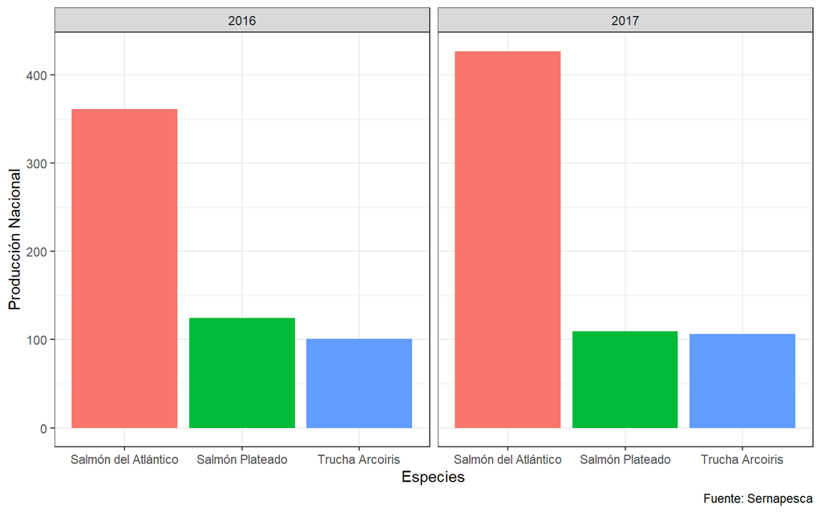

```r
 ggplot(datos1, aes(x= Especies, y= ProdNac, fill=Especies))+
   geom_col()+
  labs(y= "Producción Nacional", x= "Especies",
       caption = "Fuente: Sernapesca")+
   expand_limits(y=0)+
   facet_wrap(~ Year)+
   guides(fill=FALSE, color=FALSE)+
   theme_bw()
```

### **Ejercicio 8.** **Graficar scatter plot con ggplot ()**

Con el conjunto de datos **datos1** realice un gráfico de dispersión donde la variable X=**DispOvas** y la variable Y =**ProdNac**. Colore por especies.Además, use el comando expand_limits(y=0) para que el eje Y comience en cero.

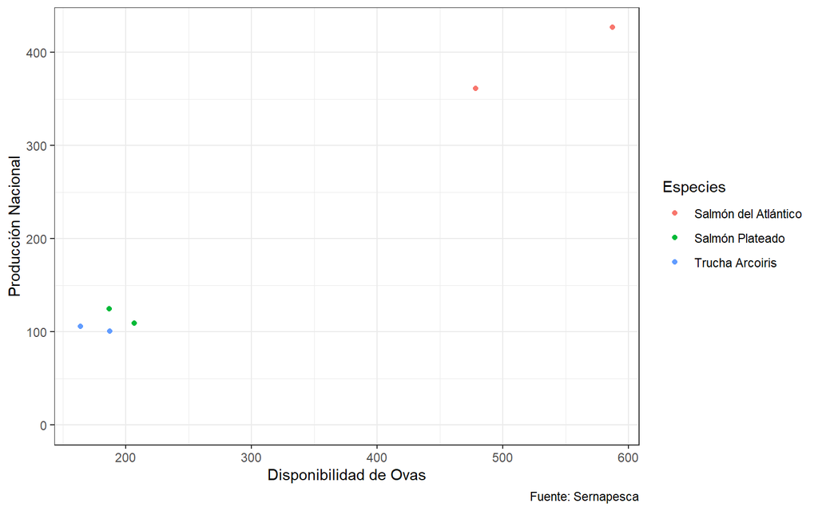

```r
 ggplot(datos1, aes(x= DispOvas, y= ProdNac, color=Especies))+
   geom_point()+
  labs(y= "Producción Nacional", x= "Disponibilidad de Ovas",
       caption = "Fuente: Sernapesca")+
   expand_limits(y=0)+
   theme_bw()
```

### **Ejercicio 9.** **Importar la base de Datos2**

Cree un objeto llamado **datos2** e importe el set de datos **Datos2** usando la función *read_excel()* de la librería **readxl**. Explore el set de datos usando las funciones **head()** y **str()**.

```r
datos2 <- read_excel("Datos2.xlsx")
head(datos2)
```

```
## # A tibble: 6 x 4
##   Mes     Region_Lagos Region_Aysen Region_Magallanes
##   <chr>          <dbl>        <dbl>             <dbl>
## 1 Enero             NA            1                NA
## 2 Febrero           NA            1                 1
## 3 Marzo              2            2                 1
## 4 Abril             NA            2                 4
## 5 Mayo               1            3                NA
## 6 Junio             NA            6                 2
```

```r
str(datos2)
```

```
## tibble[,4] [12 x 4] (S3: tbl_df/tbl/data.frame)
##  $ Mes              : chr [1:12] "Enero" "Febrero" "Marzo" "Abril" ...
##  $ Region_Lagos     : num [1:12] NA NA 2 NA 1 NA 4 NA NA 1 ...
##  $ Region_Aysen     : num [1:12] 1 1 2 2 3 6 NA NA NA 1 ...
##  $ Region_Magallanes: num [1:12] NA 1 1 4 NA 2 NA 1 NA 1 ...
```

### **Ejercicio 10.** **Reemplazar valores faltantes**

Reemplace los valores faltantes **NA** por **0** de las variables Region_Lagos, Region_Aysen y Region_Magallanes de la base de datos **datos2**. Use la función *replace_na()* y como argumento de esta función haga una **lista** con estas variables e igualelas a cero.

```r
datos2 %>%
replace_na(list(Region_Lagos = 0, Region_Aysen = 0, Region_Magallanes = 0)) %>%
  mutate(Region_Lagos =Region_Lagos, Region_Aysen = Region_Aysen,
         Region_Magallanes = Region_Magallanes)
```

```
## # A tibble: 12 x 4
##    Mes        Region_Lagos Region_Aysen Region_Magallanes
##    <chr>             <dbl>        <dbl>             <dbl>
##  1 Enero                 0            1                 0
##  2 Febrero               0            1                 1
##  3 Marzo                 2            2                 1
##  4 Abril                 0            2                 4
##  5 Mayo                  1            3                 0
##  6 Junio                 0            6                 2
##  7 Julio                 4            0                 0
##  8 Agosto                0            0                 1
##  9 Septiembre            0            0                 0
## 10 Octubre               1            1                 1
## 11 Noviembre             1            0                 1
## 12 Diciembre             0            4                 0
```

### **Ejercicio 11.** **Generar variables derivadas**

Genere una nueva variable llamada **NTotal** a partir de la suma de los datos de las variables Region_Lagos, Region_Aysen y Region_Magallanes de la base de datos **datos2** generada en el **ejercicio 10**. También, genere una variable llamada **Per_NTotal** que es el porcentaje mensual de casos de ISA confirmados. Use la función *mutate*.

```r
datos2 %>%
replace_na(list(Region_Lagos = 0, Region_Aysen = 0, Region_Magallanes = 0)) %>%
  mutate(Region_Lagos =Region_Lagos, Region_Aysen = Region_Aysen,
         Region_Magallanes = Region_Magallanes,
         NTotal =    Region_Lagos+Region_Aysen+Region_Magallanes,
         Per_NTotal = (NTotal/sum(NTotal))*100)
```

```
## # A tibble: 12 x 6
##    Mes        Region_Lagos Region_Aysen Region_Magallanes NTotal Per_NTotal
##    <chr>             <dbl>        <dbl>             <dbl>  <dbl>      <dbl>
##  1 Enero                 0            1                 0      1        2.5
##  2 Febrero               0            1                 1      2        5
##  3 Marzo                 2            2                 1      5       12.5
##  4 Abril                 0            2                 4      6       15
##  5 Mayo                  1            3                 0      4       10
##  6 Junio                 0            6                 2      8       20
##  7 Julio                 4            0                 0      4       10
##  8 Agosto                0            0                 1      1        2.5
##  9 Septiembre            0            0                 0      0        0
## 10 Octubre               1            1                 1      3        7.5
## 11 Noviembre             1            0                 1      2        5
## 12 Diciembre             0            4                 0      4       10
```

### **Ejercicio 12.** **Realizar diagrama de barras**

Cargue la base de datos **datos2_new.txt**, estos datos son los que se generaron con la información del ejercicio anterior. Use la función *ggplot()* para realizar un diagrama de barras con la variables **X** = Mes, e **Y** = NTotal. Para hacer el gráfico de barras primero, debes volver la variable meses **factor** y sus levels deben ser cada uno de los meses en orden, esto es para que en el eje de la **X** queden organizadas las etiquetas según los meses del año. Colore las barras por mes.Además, use el comando expand_limits(y=0) para que el eje Y comience en cero.

```r
datos2_new<-read.table("datos2_new.txt", header = TRUE, sep = " ")

datos2_new[,1] <- factor(datos2_new$Mes,
                         levels= c("Enero","Febrero","Marzo","Abril","Mayo",
                                   "Junio","Julio","Agosto","Septiembre",                                           "Octubre","Noviembre","Diciembre") )
datos2_new
```

```
##           Mes Region_Lagos Region_Aysen Region_Magallanes NTotal Per_NTotal
## 1       Enero            0            1                 0      1        2.5
## 2     Febrero            0            1                 1      2        5.0
## 3       Marzo            2            2                 1      5       12.5
## 4       Abril            0            2                 4      6       15.0
## 5        Mayo            1            3                 0      4       10.0
## 6       Junio            0            6                 2      8       20.0
## 7       Julio            4            0                 0      4       10.0
## 8      Agosto            0            0                 1      1        2.5
## 9  Septiembre            0            0                 0      0        0.0
## 10    Octubre            1            1                 1      3        7.5
## 11  Noviembre            1            0                 1      2        5.0
## 12  Diciembre            0            4                 0      4       10.0
```

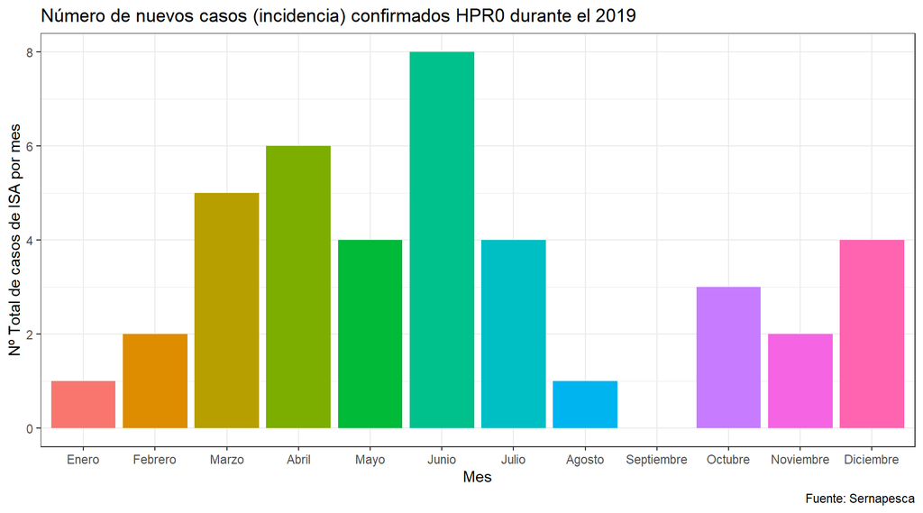

```r
ggplot(datos2_new, aes(x=Mes, y= NTotal, fill= Mes))+
  geom_col() +
  expand_limits(y=0)+
  labs(title= "Número de nuevos casos (incidencia) confirmados HPR0 durante el 2019",
       y= "Nº Total de casos de ISA por mes", x= "Mes",
       caption = "Fuente: Sernapesca")+
  guides(fill=FALSE, color=FALSE)+
  theme_bw()
```